# Part 4 - Productivity with Pandas

# Table of Contents

In the previous notebook, we introduced **[Pandas](https://pandas.pydata.org/)**, which provides high-level data structures and functions designed to make working with structured or tabular data fast, easy, and expressive.

In this notebook, we will build on our knowledge of Pandas to be more productive. Pandas provides sophisticated, multi-level indexing functionality, along with the ability to perform data aggregation operations, such as grouping, merging, and joining data. It also provides capabilities for working with Time Series data that involves navigating and manipulating various date ranges and time indices. Let's dive into the details.

```python
# Import libraries
import pandas as pd
import numpy as np
```

## Working with Categorical Data

In many practical Data Science activities, you may come across data that contain categorical variables. These variables are typically stored as text values in columns. For such data, you may want to find the unique elements, frequency of each category present, or transform the categorical data into suitable numeric values.

**Pandas** provides various approaches to handle categorical data. To get started, let's create a small dataset and look at some examples. **Seaborn** library comes preloaded with some sample datasets. We will load the `tips` data from `seaborn` for our analysis.

```python
import seaborn as sns
tips_data = sns.load_dataset('tips')
print(tips_data.head())
```

```
   total_bill   tip     sex smoker  day    time  size
0       16.99  1.01  Female     No  Sun  Dinner     2
1       10.34  1.66    Male     No  Sun  Dinner     3
2       21.01  3.50    Male     No  Sun  Dinner     3
3       23.68  3.31    Male     No  Sun  Dinner     2
4       24.59  3.61  Female     No  Sun  Dinner     4
```

### Unique Values and Value Counts

**Pandas** provides methods such as `unique()`, `nunique()`, and `value_counts()` to extract information about the values in a column.

#### `unique()` and `nunique()`

`unique()` can be used to identify the unique elements of a column.

```python
tips_data['day'].unique()
```

```
[Sun, Sat, Thur, Fri]
Categories (4, object): [Sun, Sat, Thur, Fri]
```

The result is an `array` which can be easily converted to a list by chaining the `tolist()` function.

```python
tips_data['day'].unique().tolist()
```

```
['Sun', 'Sat', 'Thur', 'Fri']
```

Similarly, `unique()` can be applied on the `index`.

```python
indexed_tip = tips_data.set_index('day')
indexed_tip.head()
```

| day | total_bill | tip | sex | smoker | time | size |
| --- | --- | --- | --- | --- | --- | --- |
| Sun | 16.99 | 1.01 | Female | No | Dinner | 2 |
| Sun | 10.34 | 1.66 | Male | No | Dinner | 3 |
| Sun | 21.01 | 3.50 | Male | No | Dinner | 3 |
| Sun | 23.68 | 3.31 | Male | No | Dinner | 2 |
| Sun | 24.59 | 3.61 | Female | No | Dinner | 4 |

```python
indexed_tip.index.unique()
```

```
CategoricalIndex(['Sun', 'Sat', 'Thur', 'Fri'], categories=['Sun', 'Sat', 'Thur', 'Fri'], ordered=False, name='day', dtype='category')
```

**`nunique()`** can be used to count the number of unique values in a column.

```python
# Count of unique values in employee
tips_data['day'].nunique()
```

```
4
```

```python
# Count of unique values in skills
tips_data['time'].nunique()
```

```
2
```

#### `value_counts()`

`value_counts()` are used to determine the frequency of different values present in the column.

```python
tips_data['day'].value_counts()
```

```
Sat     87
Sun     76
Thur    62
Fri     19
Name: day, dtype: int64
```

`reset_index()` can be chained to the `value_counts()` operation to easily get the results as a `DataFrame`.

```python
days_df = tips_data['day'].value_counts().reset_index()
days_df
```

|  | index | day |
| --- | --- | --- |
| 0 | Sat | 87 |
| 1 | Sun | 76 |
| 2 | Thur | 62 |
| 3 | Fri | 19 |

### One Hot Encoding

Many machine learning algorithms do not support the presence of categorical values in data. Pandas provides various approaches to transform the categorical data into suitable numeric values to create *dummy variables*, and one such approach is called **One Hot Encoding**. The basic strategy is to convert each category value into a new column and assign a `0 or 1` (True/False) value to the column. Dummy variables can be created using `get_dummies`.

```python
pd.get_dummies(tips_data, columns=['day'])
```

|  | total_bill | tip | sex | smoker | time | size | day_Thur | day_Fri | day_Sat | day_Sun |
| --- | --- | --- | --- | --- | --- | --- | --- | --- | --- | --- |
| 0 | 16.99 | 1.01 | Female | No | Dinner | 2 | 0 | 0 | 0 | 1 |
| 1 | 10.34 | 1.66 | Male | No | Dinner | 3 | 0 | 0 | 0 | 1 |
| 2 | 21.01 | 3.50 | Male | No | Dinner | 3 | 0 | 0 | 0 | 1 |
| 3 | 23.68 | 3.31 | Male | No | Dinner | 2 | 0 | 0 | 0 | 1 |
| 4 | 24.59 | 3.61 | Female | No | Dinner | 4 | 0 | 0 | 0 | 1 |
| ... | ... | ... | ... | ... | ... | ... | ... | ... | ... | ... |
| 239 | 29.03 | 5.92 | Male | No | Dinner | 3 | 0 | 0 | 1 | 0 |
| 240 | 27.18 | 2.00 | Female | Yes | Dinner | 2 | 0 | 0 | 1 | 0 |
| 241 | 22.67 | 2.00 | Male | Yes | Dinner | 2 | 0 | 0 | 1 | 0 |
| 242 | 17.82 | 1.75 | Male | No | Dinner | 2 | 0 | 0 | 1 | 0 |
| 243 | 18.78 | 3.00 | Female | No | Dinner | 2 | 1 | 0 | 0 | 0 |

244 rows × 10 columns

The resulting dataset contains four new columns (one for each day) `day_Thur, day_Fri, day_Sat, day_Sun`. You can pass as many category columns as you would like and choose how to label the columns using `prefix` parameter.

```python
pd.get_dummies(tips_data, columns=['day', 'smoker', 'sex'], prefix=['weekday', 'smokes', 'gender'])
```

|  | total_bill | tip | time | size | weekday_Thur | weekday_Fri | weekday_Sat | weekday_Sun | smokes_Yes | smokes_No | gender_Male | gender_Female |
| --- | --- | --- | --- | --- | --- | --- | --- | --- | --- | --- | --- | --- |
| 0 | 16.99 | 1.01 | Dinner | 2 | 0 | 0 | 0 | 1 | 0 | 1 | 0 | 1 |
| 1 | 10.34 | 1.66 | Dinner | 3 | 0 | 0 | 0 | 1 | 0 | 1 | 1 | 0 |
| 2 | 21.01 | 3.50 | Dinner | 3 | 0 | 0 | 0 | 1 | 0 | 1 | 1 | 0 |
| 3 | 23.68 | 3.31 | Dinner | 2 | 0 | 0 | 0 | 1 | 0 | 1 | 1 | 0 |
| 4 | 24.59 | 3.61 | Dinner | 4 | 0 | 0 | 0 | 1 | 0 | 1 | 0 | 1 |
| ... | ... | ... | ... | ... | ... | ... | ... | ... | ... | ... | ... | ... |
| 239 | 29.03 | 5.92 | Dinner | 3 | 0 | 0 | 1 | 0 | 0 | 1 | 1 | 0 |
| 240 | 27.18 | 2.00 | Dinner | 2 | 0 | 0 | 1 | 0 | 1 | 0 | 0 | 1 |
| 241 | 22.67 | 2.00 | Dinner | 2 | 0 | 0 | 1 | 0 | 1 | 0 | 1 | 0 |
| 242 | 17.82 | 1.75 | Dinner | 2 | 0 | 0 | 1 | 0 | 0 | 1 | 1 | 0 |
| 243 | 18.78 | 3.00 | Dinner | 2 | 1 | 0 | 0 | 0 | 0 | 1 | 0 | 1 |

244 rows × 12 columns

### Binning Continous Variables

You may come across scenarios where you need to bin continuous data into discrete chunks to be used as a categorical variable. We can use **`pd.cut()`** function to cut our data into discrete buckets.

```python
# Bin data into 5 equal sized buckets
pd.cut(tips_data['total_bill'], bins=5)
```

```
0      (12.618, 22.166]
1       (3.022, 12.618]
2      (12.618, 22.166]
3      (22.166, 31.714]
4      (22.166, 31.714]
             ...
239    (22.166, 31.714]
240    (22.166, 31.714]
241    (22.166, 31.714]
242    (12.618, 22.166]
243    (12.618, 22.166]
Name: total_bill, Length: 244, dtype: category
Categories (5, interval[float64]): [(3.022, 12.618] < (12.618, 22.166] < (22.166, 31.714] < (31.714, 41.262] < (41.262, 50.81]]
```

The function results in five equal-width bins. We can also specify bin edges to create specific *non-uniform* bins.

```python
# Bin data by specifying bin edges
bill_cat = pd.cut(tips_data['total_bill'], bins=[0, 31.714, 50.81])
bill_cat
```

```
0      (0.0, 31.714]
1      (0.0, 31.714]
2      (0.0, 31.714]
3      (0.0, 31.714]
4      (0.0, 31.714]
           ...
239    (0.0, 31.714]
240    (0.0, 31.714]
241    (0.0, 31.714]
242    (0.0, 31.714]
243    (0.0, 31.714]
Name: total_bill, Length: 244, dtype: category
Categories (2, interval[float64]): [(0.0, 31.714] < (31.714, 50.81]]
```

```python
# Value count for each category
bill_cat.value_counts()
```

```
(0.0, 31.714]      218
(31.714, 50.81]     26
Name: total_bill, dtype: int64
```

The operation creates two non-uniform categories for `total_bill`.

## Data Aggregation

Summarizing data by applying various aggregation functions such as `sum()`, `mean()`, `median()` etc. to each group or category within the data is a critical component of a data analysis workflow. Simple aggregations can give you a high level overview but are often not enough to get a deeper understanding of the data.

**Pandas** provides a flexible `groupby()` operation which allows for quick and efficient aggregation on subsets of data.

### GroupBy

The name "group by" comes from a command in the SQL language. Hadley Wickham, author of popular packages in [R](https://www.r-project.org/about.html) programming language, described grouping operations by coining the term *split-apply-combine*.

- The *split* step breaks up and groups a DataFrame based on the value of the specified key. Splitting is performed on a particular axis of a DataFrame i.e. rows (axis=0) or columns (axis=1).
- The *apply* step computes some aggregation function within the individual groups.
- The *combine* step merges the results of these operations into an output array.

The image below shows a mockup of a simple group aggregation.

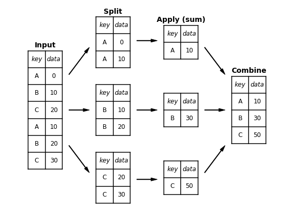

`groupby()` method can be used to apply the basic *split-apply-combine* operation on a DataFrame by specifying the desired column name.

```python
# Apply Group By
grp1 = tips_data.groupby('sex')
grp1
```

```
<pandas.core.groupby.generic.DataFrameGroupBy object at 0x7ff1186b91c0>
```

The method returns a `DataFrameGroupBy` object. No actual computation has been performed by the `groupby()` method yet. The idea is that this object has all the information needed to then apply some operation to each of the groups in the data. This "lazy evaluation" approach means that common aggregation functions can be implemented very efficiently using `groupby()`. For example, to compute the mean, we can call `mean()` method on the *GroupBy* object.

```python
# Compute mean
grp1.mean()
```

| sex | total_bill | tip | size |
| --- | --- | --- | --- |
| Male | 20.744076 | 3.089618 | 2.630573 |
| Female | 18.056897 | 2.833448 | 2.459770 |

The data has been aggregated according to the group key and is now indexed by the unique values in the `sex` column. By default, all of the numeric columns are aggregated.

#### Using Multiple Keys

Multiple column names can be passed as group keys to group the data appropriately. Let's group the data by `smoker` and `day` columns.

```python
# Aggregation using multiple keys
tips_data.groupby(['smoker', 'day']).mean()
```

| smoker | day | total_bill | tip | size |
| --- | --- | --- | --- | --- |
| Yes | Thur | 19.190588 | 3.030000 | 2.352941 |
|  | Fri | 16.813333 | 2.714000 | 2.066667 |
|  | Sat | 21.276667 | 2.875476 | 2.476190 |
|  | Sun | 24.120000 | 3.516842 | 2.578947 |
| No | Thur | 17.113111 | 2.673778 | 2.488889 |
|  | Fri | 18.420000 | 2.812500 | 2.250000 |
|  | Sat | 19.661778 | 3.102889 | 2.555556 |
|  | Sun | 20.506667 | 3.167895 | 2.929825 |

The data is now indexed by the unique values in the `smoker` and `day` columns. Similarly, other aggregation operations such as `sum()`, `median()`, `std()` etc. can be applied to the groups within data.

```python
# Sum operation
tips_data.groupby(['smoker', 'day']).sum()
```

| smoker | day | total_bill | tip | size |
| --- | --- | --- | --- | --- |
| Yes | Thur | 326.24 | 51.51 | 40 |
|  | Fri | 252.20 | 40.71 | 31 |
|  | Sat | 893.62 | 120.77 | 104 |
|  | Sun | 458.28 | 66.82 | 49 |
| No | Thur | 770.09 | 120.32 | 112 |
|  | Fri | 73.68 | 11.25 | 9 |
|  | Sat | 884.78 | 139.63 | 115 |
|  | Sun | 1168.88 | 180.57 | 167 |

```python
# Median operation
tips_data.groupby(['smoker', 'day']).median()
```

| smoker | day | total_bill | tip | size |
| --- | --- | --- | --- | --- |
| Yes | Thur | 16.470 | 2.560 | 2 |
|  | Fri | 13.420 | 2.500 | 2 |
|  | Sat | 20.390 | 2.690 | 2 |
|  | Sun | 23.100 | 3.500 | 2 |
| No | Thur | 15.950 | 2.180 | 2 |
|  | Fri | 19.235 | 3.125 | 2 |
|  | Sat | 17.820 | 2.750 | 2 |
|  | Sun | 18.430 | 3.020 | 3 |

```python
# Standard Deviation operation
tips_data.groupby(['smoker', 'day']).std()
```

| smoker | day | total_bill | tip | size |
| --- | --- | --- | --- | --- |
| Yes | Thur | 8.355149 | 1.113491 | 0.701888 |
|  | Fri | 9.086388 | 1.077668 | 0.593617 |
|  | Sat | 10.069138 | 1.630580 | 0.862161 |
|  | Sun | 10.442511 | 1.261151 | 0.901591 |
| No | Thur | 7.721728 | 1.282964 | 1.179796 |
|  | Fri | 5.059282 | 0.898494 | 0.500000 |
|  | Sat | 8.939181 | 1.642088 | 0.784960 |
|  | Sun | 8.130189 | 1.224785 | 1.032674 |

#### Using `aggregate()`

`aggregate()` method allows for even greater flexibility by taking a string, a function, or a list and computing all the aggregates at once. The example below shows minimum aggregation operation being used as a string, median being called as a function, and all aggregation operations being passed as a list.

```python
tips_data.groupby(['smoker', 'day']).aggregate(['min', np.median, max])
```

| smoker | day | total_bill min | total_bill median | total_bill max | tip min | tip median | tip max | size min | size median | size max |
| --- | --- | --- | --- | --- | --- | --- | --- | --- | --- | --- |
| Yes | Thur | 10.34 | 16.470 | 43.11 | 2.00 | 2.560 | 5.00 | 2 | 2 | 4 |
|  | Fri | 5.75 | 13.420 | 40.17 | 1.00 | 2.500 | 4.73 | 1 | 2 | 4 |
|  | Sat | 3.07 | 20.390 | 50.81 | 1.00 | 2.690 | 10.00 | 1 | 2 | 5 |
|  | Sun | 7.25 | 23.100 | 45.35 | 1.50 | 3.500 | 6.50 | 2 | 2 | 5 |
| No | Thur | 7.51 | 15.950 | 41.19 | 1.25 | 2.180 | 6.70 | 1 | 2 | 6 |
|  | Fri | 12.46 | 19.235 | 22.75 | 1.50 | 3.125 | 3.50 | 2 | 2 | 3 |
|  | Sat | 7.25 | 17.820 | 48.33 | 1.00 | 2.750 | 9.00 | 1 | 2 | 4 |
|  | Sun | 8.77 | 18.430 | 48.17 | 1.01 | 3.020 | 6.00 | 2 | 3 | 6 |

Aggregation functions can also be passed as a dictionary, mapping column names to operations that are to be applied on that column. The example below shows `min` operation applied to `total_bill` column and `max` operation applied to `tip` column.

```python
tips_data.groupby(['smoker', 'day']).aggregate({'total_bill':'min', 'tip':'max'})
```

| smoker | day | total_bill | tip |
| --- | --- | --- | --- |
| Yes | Thur | 10.34 | 5.00 |
|  | Fri | 5.75 | 4.73 |
|  | Sat | 3.07 | 10.00 |
|  | Sun | 7.25 | 6.50 |
| No | Thur | 7.51 | 6.70 |
|  | Fri | 12.46 | 3.50 |
|  | Sat | 7.25 | 9.00 |
|  | Sun | 8.77 | 6.00 |

A more complex operation could involve passing a list of operations to be applied to a specific column.

```python
tips_data.groupby(['smoker', 'day']).aggregate({'total_bill':['min','max','count'], 'tip':'max'})
```

| smoker | day | total_bill min | total_bill max | total_bill count | tip max |
| --- | --- | --- | --- | --- | --- |
| Yes | Thur | 10.34 | 43.11 | 17 | 5.00 |
|  | Fri | 5.75 | 40.17 | 15 | 4.73 |
|  | Sat | 3.07 | 50.81 | 42 | 10.00 |
|  | Sun | 7.25 | 45.35 | 19 | 6.50 |
| No | Thur | 7.51 | 41.19 | 45 | 6.70 |
|  | Fri | 12.46 | 22.75 | 4 | 3.50 |
|  | Sat | 7.25 | 48.33 | 45 | 9.00 |
|  | Sun | 8.77 | 48.17 | 57 | 6.00 |

#### Selecting a Subset of Columns

For large datasets, it may be desirable to aggregate a specific column or only a subset of columns. As an example, we can group the data by `smoker` and compute mean for `tip` column as follows:

```python
tips_data.groupby(['smoker'])['tip'].mean()
```

```
smoker
Yes    3.008710
No     2.991854
Name: tip, dtype: float64
```

Similarly, we can group the data by `smoker` and `day` columns, compute median for `tip` column.

```python
tips_data.groupby(['smoker','day'])['tip'].median()
```

```
smoker  day
Yes     Thur    2.560
        Fri     2.500
        Sat     2.690
        Sun     3.500
No      Thur    2.180
        Fri     3.125
        Sat     2.750
        Sun     3.020
Name: tip, dtype: float64
```

### Pivot Tables

Pivot Table is a popular operation that is commonly used on tabular data in spreadsheets. The pivot table takes simple column-wise data as input, and groups the entries into a two-dimensional table that provides a multidimensional summarization of the data. Pivot Tables are essentially a multidimensional version of `GroupBy`. **Pandas** includes a `pandas.pivot_table` function and `DataFrame` also has a `pivot_table` method.

Seaborn library comes preloaded with some sample datasets. We will load the `titanic` dataset from seaborn for our analysis and look at some examples.

```python
# Get Data
titanic_df = sns.load_dataset('titanic')
titanic_df.head()
```

|  | survived | pclass | sex | age | sibsp | parch | fare | embarked | class | who | adult_male | deck | embark_town | alive | alone |
| --- | --- | --- | --- | --- | --- | --- | --- | --- | --- | --- | --- | --- | --- | --- | --- |
| 0 | 0 | 3 | male | 22.0 | 1 | 0 | 7.2500 | S | Third | man | True | NaN | Southampton | no | False |
| 1 | 1 | 1 | female | 38.0 | 1 | 0 | 71.2833 | C | First | woman | False | C | Cherbourg | yes | False |
| 2 | 1 | 3 | female | 26.0 | 0 | 0 | 7.9250 | S | Third | woman | False | NaN | Southampton | yes | True |
| 3 | 1 | 1 | female | 35.0 | 1 | 0 | 53.1000 | S | First | woman | False | C | Southampton | yes | False |
| 4 | 0 | 3 | male | 35.0 | 0 | 0 | 8.0500 | S | Third | man | True | NaN | Southampton | no | True |

Let's say we want to look at the average number of people that survived by both sex and class. We can get the results using both `GroupBy` and `pivot_table`.

- Using `GroupBy`

```python
titanic_df.groupby(['sex', 'class'])['survived'].aggregate('mean').unstack()
```

| class sex | First | Second | Third |
| --- | --- | --- | --- |
| female | 0.968085 | 0.921053 | 0.500000 |
| male | 0.368852 | 0.157407 | 0.135447 |

- Using `pivot_table`

```python
titanic_df.pivot_table(values='survived', index='sex', columns='class')
```

| class sex | First | Second | Third |
| --- | --- | --- | --- |
| female | 0.968085 | 0.921053 | 0.500000 |
| male | 0.368852 | 0.157407 | 0.135447 |

We can see that the `pivot_table` approach is much more readable than the `GroupBy` and produces the same result. The default aggregation operation is *mean*.

#### Multi-level Pivot Table

Just as in `GroupBy`, the data can be grouped at multiple levels using `pivot_table`. Suppose we want to group survival by `sex` and `age`. Since `age` is a continuous variable, we can create bins for `age` using `pd.cut` function and then group the data.

```python
# Create bins for Age
age = pd.cut(titanic_df['age'], bins=[0,18,80])
age
```

```
0      (18.0, 80.0]
1      (18.0, 80.0]
2      (18.0, 80.0]
3      (18.0, 80.0]
4      (18.0, 80.0]
           ...
886    (18.0, 80.0]
887    (18.0, 80.0]
888             NaN
889    (18.0, 80.0]
890    (18.0, 80.0]
Name: age, Length: 891, dtype: category
Categories (2, interval[int64]): [(0, 18] < (18, 80]]
```

```python
# Group data
titanic_df.pivot_table(values='survived', index=['sex', age], columns='class')
```

| sex | class age | First | Second | Third |
| --- | --- | --- | --- | --- |
| female | (0, 18] | 0.909091 | 1.000000 | 0.511628 |
|  | (18, 80] | 0.972973 | 0.900000 | 0.423729 |
| male | (0, 18] | 0.800000 | 0.600000 | 0.215686 |
|  | (18, 80] | 0.375000 | 0.071429 | 0.133663 |

The operation can be applied to columns in a similar fashion. Suppose we want to group survival by `sex` and `age` and look at the data by `class` and `fare`.

We can discretize the `fare` variable into equal-sized buckets based on sample quantiles using `pd.qcut` and then group the data.

```python
# Create bins for fare
fare = pd.qcut(titanic_df['fare'], q=2)
```

```python
# Group data
titanic_df.pivot_table(values='survived', index=['sex', age], columns=[fare, 'class'])
```

| sex | fare class age | (-0.001, 14.454] First | (-0.001, 14.454] Second | (-0.001, 14.454] Third | (14.454, 512.329] First | (14.454, 512.329] Second | (14.454, 512.329] Third |
| --- | --- | --- | --- | --- | --- | --- | --- |
| female | (0, 18] | NaN | 1.000000 | 0.714286 | 0.909091 | 1.000000 | 0.318182 |
|  | (18, 80] | NaN | 0.880000 | 0.444444 | 0.972973 | 0.914286 | 0.391304 |
| male | (0, 18] | NaN | 0.000000 | 0.260870 | 0.800000 | 0.818182 | 0.178571 |
|  | (18, 80] | 0.0 | 0.098039 | 0.125000 | 0.391304 | 0.030303 | 0.192308 |

#### Using `aggfunc`

`aggfunc` keyword can be used to specify the aggregate functions that can be applied to different columns.

```python
titanic_df.pivot_table(index='sex', columns='class',
                      aggfunc={'survived':'sum', 'fare': 'mean'})
```

| class sex | fare First | fare Second | fare Third | survived First | survived Second | survived Third |
| --- | --- | --- | --- | --- | --- | --- |
| female | 106.125798 | 21.970121 | 16.118810 | 91 | 70 | 72 |
| male | 67.226127 | 19.741782 | 12.661633 | 45 | 17 | 47 |

To compute totals along each grouping, `margins` keyword can be used.

```python
titanic_df.pivot_table(values='survived', index='sex', columns='class',
                      aggfunc='sum', margins=True)
```

| class sex | First | Second | Third | All |
| --- | --- | --- | --- | --- |
| female | 91 | 70 | 72 | 233 |
| male | 45 | 17 | 47 | 109 |
| All | 136 | 87 | 119 | 342 |

### `describe()` method

Convenience methods, such as `describe()`, can be used to compute several common aggregates for each column. It also comes in handy when you are trying to understand the overall properties of a dataset.

```python
tips_data.describe()
```

|  | total_bill | tip | size |
| --- | --- | --- | --- |
| count | 244.000000 | 244.000000 | 244.000000 |
| mean | 19.785943 | 2.998279 | 2.569672 |
| std | 8.902412 | 1.383638 | 0.951100 |
| min | 3.070000 | 1.000000 | 1.000000 |
| 25% | 13.347500 | 2.000000 | 2.000000 |
| 50% | 17.795000 | 2.900000 | 2.000000 |
| 75% | 24.127500 | 3.562500 | 3.000000 |
| max | 50.810000 | 10.000000 | 6.000000 |

#### `describe()` on GroupBy

`describe()` can be used on a `groupby()` object to get common aggregates for a subset of data.

```python
tips_data.groupby(['smoker','day'])['total_bill'].describe()
```

| smoker | day | count | mean | std | min | 25% | 50% | 75% | max |
| --- | --- | --- | --- | --- | --- | --- | --- | --- | --- |
| Yes | Thur | 17.0 | 19.190588 | 8.355149 | 10.34 | 13.510 | 16.470 | 19.8100 | 43.11 |
|  | Fri | 15.0 | 16.813333 | 9.086388 | 5.75 | 11.690 | 13.420 | 18.6650 | 40.17 |
|  | Sat | 42.0 | 21.276667 | 10.069138 | 3.07 | 13.405 | 20.390 | 26.7925 | 50.81 |
|  | Sun | 19.0 | 24.120000 | 10.442511 | 7.25 | 17.165 | 23.100 | 32.3750 | 45.35 |
| No | Thur | 45.0 | 17.113111 | 7.721728 | 7.51 | 11.690 | 15.950 | 20.2700 | 41.19 |
|  | Fri | 4.0 | 18.420000 | 5.059282 | 12.46 | 15.100 | 19.235 | 22.5550 | 22.75 |
|  | Sat | 45.0 | 19.661778 | 8.939181 | 7.25 | 14.730 | 17.820 | 20.6500 | 48.33 |
|  | Sun | 57.0 | 20.506667 | 8.130189 | 8.77 | 14.780 | 18.430 | 25.0000 | 48.17 |

## Combining Data

Data science workflows often involve combining data from different sources to enhance the analysis. There are multiple ways in which data can be combined ranging from the straightforward concatenation of two different datasets, to more complicated database-style joins.

- [pandas.concat](https://pandas.pydata.org/pandas-docs/stable/reference/api/pandas.concat.html) - stacks together objects along an axis.
- [DataFrame.append](https://pandas.pydata.org/pandas-docs/stable/reference/api/pandas.DataFrame.append.html) - works similar to `pandas.concat` but does not modify the original object. It creates a new object with the combined data.
- [pandas.merge](https://pandas.pydata.org/pandas-docs/stable/user_guide/merging.html) - joins rows in DataFrame based on one or more keys. It works as the entry point for all standard database join operations between `DataFrame` or `Series` objects.
- [DataFrame.join](https://pandas.pydata.org/pandas-docs/stable/reference/api/pandas.DataFrame.join.html) - `join` instance of a DataFrame can be used for merging by index. It can be used to combine many DataFrame objects with same or similar indexes but non-overlapping columns.

### `concat()`

`concat()` can be used to stack data frames together along an axis.

```python
# Create Data
df2 = pd.DataFrame(np.arange(6).reshape(3, 2), index=['a', 'b', 'c'],
                   columns=['one', 'two'])
print('df2 is: \n', df2)

df3 = pd.DataFrame(5 + np.arange(4).reshape(2, 2), index=['a', 'c'],
                   columns=['three', 'four'])
print('\ndf3 is: \n', df3)

df4 = pd.DataFrame(5 + np.arange(4).reshape(2, 2), index=['a', 'c'],
                   columns=['one', 'two'])
print('\ndf4 is: \n', df4)
```

```
df2 is:
    one  two
a    0    1
b    2    3
c    4    5

df3 is:
    three  four
a      5     6
c      7     8

df4 is:
    one  two
a    5    6
c    7    8
```

By default, `concat()` works row-wise within the `DataFrame` (along axis=0).

```python
pd.concat([df2,df4])
```

|  | one | two |
| --- | --- | --- |
| a | 0 | 1 |
| b | 2 | 3 |
| c | 4 | 5 |
| a | 5 | 6 |
| c | 7 | 8 |

`ignore_index` flag can be used to ignore the index when it is not necessary.

```python
pd.concat([df2,df4], ignore_index=True)
```

|  | one | two |
| --- | --- | --- |
| 0 | 0 | 1 |
| 1 | 2 | 3 |
| 2 | 4 | 5 |
| 3 | 5 | 6 |
| 4 | 7 | 8 |

You an specify an **axis** along which the concatenation should take place. If `axis` parameter is not specified, the concatenation works row-wise generating `NaN` values for unmatched columns.

```python
pd.concat([df2,df3])
```

|  | one | two | three | four |
| --- | --- | --- | --- | --- |
| a | 0.0 | 1.0 | NaN | NaN |
| b | 2.0 | 3.0 | NaN | NaN |
| c | 4.0 | 5.0 | NaN | NaN |
| a | NaN | NaN | 5.0 | 6.0 |
| c | NaN | NaN | 7.0 | 8.0 |

When `axis='columns'` is specified, the concatenation works along columns.

```python
pd.concat([df2,df3], axis='columns')
```

|  | one | two | three | four |
| --- | --- | --- | --- | --- |
| a | 0 | 1 | 5.0 | 6.0 |
| b | 2 | 3 | NaN | NaN |
| c | 4 | 5 | 7.0 | 8.0 |

### `append()`

`append()` works similar to `concat()` but does not modify the original object. It creates a new object with the combined data. The method works row-wise within the DataFrame (along axis=0). This method is not very efficient, as it involves the creation of a new index and data buffer.

```python
df2.append(df4)
```

|  | one | two |
| --- | --- | --- |
| a | 0 | 1 |
| b | 2 | 3 |
| c | 4 | 5 |
| a | 5 | 6 |
| c | 7 | 8 |

```python
df2.append(df3)
```

|  | one | two | three | four |
| --- | --- | --- | --- | --- |
| a | 0.0 | 1.0 | NaN | NaN |
| b | 2.0 | 3.0 | NaN | NaN |
| c | 4.0 | 5.0 | NaN | NaN |
| a | NaN | NaN | 5.0 | 6.0 |
| c | NaN | NaN | 7.0 | 8.0 |

### `merge()`

`merge()` joins rows in DataFrame based on one or more keys. It works as the entry point for all standard database join operations. Let's create sample data and look at some examples.

```python
# Create data
dept_df = pd.DataFrame({'employee': ['John', 'Jake', 'Jane', 'Suzi', 'Chad'],
                    'group': ['Accounting', 'Engineering', 'Engineering', 'Management', 'Marketing']})
print('dept_df is: \n', dept_df)

skills_df = pd.DataFrame({'group': ['Accounting', 'Accounting',
                              'Engineering', 'Engineering', 'Management', 'Management', 'Operations'],
                    'skills': ['math', 'spreadsheets', 'coding', 'linux',
                               'spreadsheets', 'organization', 'SAP']})
print('\nskills_df is: \n', skills_df)
```

```
dept_df is:
   employee        group
0     John   Accounting
1     Jake  Engineering
2     Jane  Engineering
3     Suzi   Management
4     Chad    Marketing

skills_df is:
          group        skills
0   Accounting          math
1   Accounting  spreadsheets
2  Engineering        coding
3  Engineering         linux
4   Management  spreadsheets
5   Management  organization
6   Operations           SAP
```

```python
# Apply merge
pd.merge(dept_df,skills_df)
```

|  | employee | group | skills |
| --- | --- | --- | --- |
| 0 | John | Accounting | math |
| 1 | John | Accounting | spreadsheets |
| 2 | Jake | Engineering | coding |
| 3 | Jake | Engineering | linux |
| 4 | Jane | Engineering | coding |
| 5 | Jane | Engineering | linux |
| 6 | Suzi | Management | spreadsheets |
| 7 | Suzi | Management | organization |

Notice that a column to *join* the data was not specified. `merge()` uses the overlapping column names as keys for joining data. It is a good practice to explicitly specify the column to join the data using `on` keyword. 'Marketing' and 'Operations' values and associated data are missing from the result as the operation returns only common set.

```python
pd.merge(dept_df,skills_df, on='group')
```

|  | employee | group | skills |
| --- | --- | --- | --- |
| 0 | John | Accounting | math |
| 1 | John | Accounting | spreadsheets |
| 2 | Jake | Engineering | coding |
| 3 | Jake | Engineering | linux |
| 4 | Jane | Engineering | coding |
| 5 | Jane | Engineering | linux |
| 6 | Suzi | Management | spreadsheets |
| 7 | Suzi | Management | organization |

If the column names are different in the `DataFrame`, then `left_on` and `right_on` keywords can be used.

```python
# Create data
emp_df = pd.DataFrame({'name': ['John', 'Jake', 'Jane', 'Suzi', 'Chad'],
                    'salary': [70000, 80000, 120000, 65000, 90000]})
emp_df
```

|  | name | salary |
| --- | --- | --- |
| 0 | John | 70000 |
| 1 | Jake | 80000 |
| 2 | Jane | 120000 |
| 3 | Suzi | 65000 |
| 4 | Chad | 90000 |

```python
# Merge
pd.merge(dept_df, emp_df, left_on='employee', right_on='name')
```

|  | employee | group | name | salary |
| --- | --- | --- | --- | --- |
| 0 | John | Accounting | John | 70000 |
| 1 | Jake | Engineering | Jake | 80000 |
| 2 | Jane | Engineering | Jane | 120000 |
| 3 | Suzi | Management | Suzi | 65000 |
| 4 | Chad | Marketing | Chad | 90000 |

The redundant column can be dropped as needed using the `drop()` method.

```python
pd.merge(dept_df, emp_df, left_on='employee', right_on='name').drop('name', axis='columns')
```

|  | employee | group | salary |
| --- | --- | --- | --- |
| 0 | John | Accounting | 70000 |
| 1 | Jake | Engineering | 80000 |
| 2 | Jane | Engineering | 120000 |
| 3 | Suzi | Management | 65000 |
| 4 | Chad | Marketing | 90000 |

#### Inner Join

By default `merge()` performs an **inner** join. The result is an intersection, or the common set found in both `DataFrame`. The merge operations we just saw were all **inner** joins. Different join types such as `left, right, outer` can be specified using the `how=` parameter.

```python
pd.merge(dept_df,skills_df, on='group', how='inner')
```

|  | employee | group | skills |
| --- | --- | --- | --- |
| 0 | John | Accounting | math |
| 1 | John | Accounting | spreadsheets |
| 2 | Jake | Engineering | coding |
| 3 | Jake | Engineering | linux |
| 4 | Jane | Engineering | coding |
| 5 | Jane | Engineering | linux |
| 6 | Suzi | Management | spreadsheets |
| 7 | Suzi | Management | organization |

'Marketing' and 'Operations' values and associated data are missing from the result, as the operation returns only common set.

#### Left Join

This join returns all records from the left DataFrame and the matched records from the right DataFrame.

```python
pd.merge(dept_df,skills_df, on='group', how='left')
```

|  | employee | group | skills |
| --- | --- | --- | --- |
| 0 | John | Accounting | math |
| 1 | John | Accounting | spreadsheets |
| 2 | Jake | Engineering | coding |
| 3 | Jake | Engineering | linux |
| 4 | Jane | Engineering | coding |
| 5 | Jane | Engineering | linux |
| 6 | Suzi | Management | spreadsheets |
| 7 | Suzi | Management | organization |
| 8 | Chad | Marketing | NaN |

The result is a Cartesian product of the rows. Since there were two 'Engineering' rows in the left DataFrame and two in the right, there are four 'Engineering' rows in the result. Similarly, there was one 'Accounting' row in left DataFrame and two in the right, resulting in two 'Accounting' rows. The row for 'Operations' is missing as this join only keeps matched rows from right DataFrame.

#### Right Join

This join returns all records from the right DataFrame and the matched records from the left DataFrame.

```python
pd.merge(dept_df,skills_df, on='group', how='right')
```

|  | employee | group | skills |
| --- | --- | --- | --- |
| 0 | John | Accounting | math |
| 1 | John | Accounting | spreadsheets |
| 2 | Jake | Engineering | coding |
| 3 | Jane | Engineering | coding |
| 4 | Jake | Engineering | linux |
| 5 | Jane | Engineering | linux |
| 6 | Suzi | Management | spreadsheets |
| 7 | Suzi | Management | organization |
| 8 | NaN | Operations | SAP |

#### Outer Join

The outer join takes the union of the keys, combining the effect of applying both left and right joins.

```python
out_df = pd.merge(dept_df,skills_df, on='group', how='outer')
out_df
```

|  | employee | group | skills |
| --- | --- | --- | --- |
| 0 | John | Accounting | math |
| 1 | John | Accounting | spreadsheets |
| 2 | Jake | Engineering | coding |
| 3 | Jake | Engineering | linux |
| 4 | Jane | Engineering | coding |
| 5 | Jane | Engineering | linux |
| 6 | Suzi | Management | spreadsheets |
| 7 | Suzi | Management | organization |
| 8 | Chad | Marketing | NaN |
| 9 | NaN | Operations | SAP |

The result is a Cartesian product of the rows using all key combinations filling in all missing values with NAs.

#### Using **index** to merge

Index can also be used as the key for merging by specifying the left_index and/or right_index flags.

```python
# Create data
dept_dfa = dept_df.set_index('group')
print('dept_dfa is \n', dept_dfa)
skills_dfa = skills_df.set_index('group')
print('\nskills_dfa is \n', skills_dfa)
```

```
dept_dfa is
             employee
group
Accounting      John
Engineering     Jake
Engineering     Jane
Management      Suzi
Marketing       Chad

skills_dfa is
                    skills
group
Accounting           math
Accounting   spreadsheets
Engineering        coding
Engineering         linux
Management   spreadsheets
Management   organization
Operations            SAP
```

```python
# Merge
pd.merge(dept_dfa, skills_dfa, left_index=True, right_index=True)
```

| group | employee | skills |
| --- | --- | --- |
| Accounting | John | math |
| Accounting | John | spreadsheets |
| Engineering | Jake | coding |
| Engineering | Jake | linux |
| Engineering | Jane | coding |
| Engineering | Jane | linux |
| Management | Suzi | spreadsheets |
| Management | Suzi | organization |

### `join()`

`join` instance of a DataFrame can also be used for merging by index. The `how` keword can be specified for the type of join.

```python
dept_dfa.join(skills_dfa, how='inner')
```

| group | employee | skills |
| --- | --- | --- |
| Accounting | John | math |
| Accounting | John | spreadsheets |
| Engineering | Jake | coding |
| Engineering | Jake | linux |
| Engineering | Jane | coding |
| Engineering | Jane | linux |
| Management | Suzi | spreadsheets |
| Management | Suzi | organization |

'Marketing' and 'Operations' values and associated data are missing from the result, as the operation returns only common set.

```python
dept_dfa.join(skills_dfa, how='outer')
```

| group | employee | skills |
| --- | --- | --- |
| Accounting | John | math |
| Accounting | John | spreadsheets |
| Engineering | Jake | coding |
| Engineering | Jake | linux |
| Engineering | Jane | coding |
| Engineering | Jane | linux |
| Management | Suzi | spreadsheets |
| Management | Suzi | organization |
| Marketing | Chad | NaN |
| Operations | NaN | SAP |

The result shows all data, filling in the missing values with NAs.

## Hierarchical Indexing

Hierarchical indexing (also known as multi-indexing) allows you to have multiple (two or more) index levels within a single index on an axis. It provides a way for representing higher dimensional data in a lower dimensional form. Let's start with a simple example, creating a series with multi-index.

### Multi-indexed Series

```python
# Create Data
index = [('CA', 2005), ('CA', 2015),
         ('NY', 2005), ('NY', 2015),
         ('TX', 2005), ('TX', 2015)]
population = [33871648, 37253956,
               18976457, 19378102,
               20851820, 25145561]
pop_series = pd.Series(population, index=index)
pop_series
```

```
(CA, 2005)    33871648
(CA, 2015)    37253956
(NY, 2005)    18976457
(NY, 2015)    19378102
(TX, 2005)    20851820
(TX, 2015)    25145561
dtype: int64
```

With this indexing, you can easily index or slice the series using the index. However, what if you wanted to select all the values for 2015? The tuple-based index is essentially a multi-index and **Pandas** `MultiIndex` type allows us to create multi-level indexes. This provides us with the flexibility to perform operations on indexes easily and efficiently.

We will create a multi-indexed index for `pop_series` using the `MultiIndex` type.

```python
new_index = pd.MultiIndex.from_tuples(index)
new_index.levels
```

```
FrozenList([['CA', 'NY', 'TX'], [2005, 2015]])
```

Notice that the `new_index` object contains multiple levels of indexing, the state names and the years. We can now `reindex` the `pop_series` to see hierarchical representation of the data.

```python
pop_series = pop_series.reindex(new_index)
pop_series
```

```
CA  2005    33871648
    2015    37253956
NY  2005    18976457
    2015    19378102
TX  2005    20851820
    2015    25145561
dtype: int64
```

#### Subset Selection

Subset selection of multi-indexed data is similar to what we have seen in the previous part of this guide series. Let's take a quick look.

- Select data for California

```python
pop_series['CA']
```

```
2005    33871648
2015    37253956
dtype: int64
```

- Select data from New York to Texas

```python
pop_series['NY':'TX']
```

```
NY  2005    18976457
    2015    19378102
TX  2005    20851820
    2015    25145561
dtype: int64
```

- Select data for California and Texas

```python
pop_series[['CA','TX']]
```

```
CA  2005    33871648
    2015    37253956
TX  2005    20851820
    2015    25145561
dtype: int64
```

We can now easily access the data for second index and answer our question about selecting all the values for 2015.

```python
pop_series[:,2015]
```

```
CA    37253956
NY    19378102
TX    25145561
dtype: int64
```

#### `unstack()` and `stack()`

`unstack()` method will convert a multi-indexed Series into a DataFrame, and naturally `stack()` would do the opposite.

```python
# Unstack
pop_df = pop_series.unstack()
pop_df
```

|  | 2005 | 2015 |
| --- | --- | --- |
| CA | 33871648 | 37253956 |
| NY | 18976457 | 19378102 |
| TX | 20851820 | 25145561 |

The result is a DataFrame where second level index (years) is converted to columns, and first level index (states) remains as the index of the DataFrame.

```python
# Stack
pop_df.stack()
```

```
CA  2005    33871648
    2015    37253956
NY  2005    18976457
    2015    19378102
TX  2005    20851820
    2015    25145561
dtype: int64
```

`level` can be specified to `unstack()` by a specific index level. Specifying `level=0` will unstack based on the outermost index level i.e. by 'state'.

```python
pop_series.unstack(level=0)
```

|  | CA | NY | TX |
| --- | --- | --- | --- |
| 2005 | 33871648 | 18976457 | 20851820 |
| 2015 | 37253956 | 19378102 | 25145561 |

Specifying `level=1` unstacks by the inner index, in this case 'year'.

```python
pop_series.unstack(level=1)
```

|  | 2005 | 2015 |
| --- | --- | --- |
| CA | 33871648 | 37253956 |
| NY | 18976457 | 19378102 |
| TX | 20851820 | 25145561 |

### Multi-indexed DataFrame

In a `DataFrame`, both rows and columns can have multiple levels of indices. Let's create some sample data and take a look.

```python
# hierarchical indices and columns
index = pd.MultiIndex.from_product([[2019, 2018], [2, 1]],
                                   names=['year', 'quarter'])
columns = pd.MultiIndex.from_product([['John', 'Jane', 'Ben'], ['Product A', 'Product B']],
                                     names=['sales person', 'product'])

# mock some data
data = np.round(np.random.randn(4, 6), 1)
data[:, ::2] *= 10
data += 55

# create the DataFrame
sales_data = pd.DataFrame(data, index=index, columns=columns)
sales_data
```

| year | sales person product quarter | John Product A | John Product B | Jane Product A | Jane Product B | Ben Product A | Ben Product B |
| --- | --- | --- | --- | --- | --- | --- | --- |
| 2019 | 2 | 49.0 | 56.3 | 54.0 | 55.4 | 48.0 | 54.5 |
|  | 1 | 51.0 | 55.7 | 58.0 | 53.5 | 67.0 | 52.9 |
| 2018 | 2 | 43.0 | 54.9 | 52.0 | 55.9 | 46.0 | 55.0 |
|  | 1 | 39.0 | 55.6 | 62.0 | 56.3 | 39.0 | 55.2 |

`sales_data` is essentially four dimensional data with 'sales person', 'product', 'year' and 'quarter' as its dimensions.

#### Subset Selection

Since columns in a `DataFrame` are individual `Series`, the syntax used for multi-indexed `Series` applies to the columns.

- Select data for 'Product A' sold by John

```python
sales_data['John','Product A']
```

```
year  quarter
2019  2          49.0
      1          51.0
2018  2          43.0
      1          39.0
Name: (John, Product A), dtype: float64
```

- Select data for John and Jane

```python
sales_data[['John','Jane']]
```

| year | sales person product quarter | John Product A | John Product B | Jane Product A | Jane Product B |
| --- | --- | --- | --- | --- | --- |
| 2019 | 2 | 49.0 | 56.3 | 54.0 | 55.4 |
|  | 1 | 51.0 | 55.7 | 58.0 | 53.5 |
| 2018 | 2 | 43.0 | 54.9 | 52.0 | 55.9 |
|  | 1 | 39.0 | 55.6 | 62.0 | 56.3 |

**`.loc`** and **`.iloc`** index operators can also be used.

- Sales data for first two rows and first four columns

```python
sales_data.iloc[:2, :4]
```

| year | sales person product quarter | John Product A | John Product B | Jane Product A | Jane Product B |
| --- | --- | --- | --- | --- | --- |
| 2019 | 2 | 49.0 | 56.3 | 54.0 | 55.4 |
|  | 1 | 51.0 | 55.7 | 58.0 | 53.5 |

- Jane's sales in 2019

```python
sales_data.loc[2019,'Jane']
```

| product quarter | Product A | Product B |
| --- | --- | --- |
| 2 | 54.0 | 55.4 |
| 1 | 58.0 | 53.5 |

- Jane's sales in 2019 for Product B

```python
sales_data.loc[2019,('Jane','Product B')]
```

```
quarter
2    55.4
1    53.5
Name: (Jane, Product B), dtype: float64
```

- Jane's sales in second quarter of 2019 for Product B

```python
sales_data.loc[(2019,2), ('Jane','Product B')]
```

```
55.4
```

#### Sorting

##### By Index and Level

`sort_index()` can be used to sort the index or levels within your data. By default, the indexing operartion is performed on the outermost index (level=0) and in ascending order.

```python
sales_data.sort_index()
```

| year | sales person product quarter | John Product A | John Product B | Jane Product A | Jane Product B | Ben Product A | Ben Product B |
| --- | --- | --- | --- | --- | --- | --- | --- |
| 2018 | 1 | 39.0 | 55.6 | 62.0 | 56.3 | 39.0 | 55.2 |
|  | 2 | 43.0 | 54.9 | 52.0 | 55.9 | 46.0 | 55.0 |
| 2019 | 1 | 51.0 | 55.7 | 58.0 | 53.5 | 67.0 | 52.9 |
|  | 2 | 49.0 | 56.3 | 54.0 | 55.4 | 48.0 | 54.5 |

Specifying `level=1` sorts by the inner index.

```python
sales_data.sort_index(level=1)
```

| year | sales person product quarter | John Product A | John Product B | Jane Product A | Jane Product B | Ben Product A | Ben Product B |
| --- | --- | --- | --- | --- | --- | --- | --- |
| 2018 | 1 | 39.0 | 55.6 | 62.0 | 56.3 | 39.0 | 55.2 |
| 2019 | 1 | 51.0 | 55.7 | 58.0 | 53.5 | 67.0 | 52.9 |
| 2018 | 2 | 43.0 | 54.9 | 52.0 | 55.9 | 46.0 | 55.0 |
| 2019 | 2 | 49.0 | 56.3 | 54.0 | 55.4 | 48.0 | 54.5 |

Sorting can be applied on columns by specifying `axis='columns'`.

```python
sales_data.sort_index(axis='columns')
```

| year | sales person product quarter | Ben Product A | Ben Product B | Jane Product A | Jane Product B | John Product A | John Product B |
| --- | --- | --- | --- | --- | --- | --- | --- |
| 2019 | 2 | 48.0 | 54.5 | 54.0 | 55.4 | 49.0 | 56.3 |
|  | 1 | 67.0 | 52.9 | 58.0 | 53.5 | 51.0 | 55.7 |
| 2018 | 2 | 46.0 | 55.0 | 52.0 | 55.9 | 43.0 | 54.9 |
|  | 1 | 39.0 | 55.2 | 62.0 | 56.3 | 39.0 | 55.6 |

```python
sales_data.sort_index(axis='columns', level=1)
```

| year | sales person product quarter | Ben Product A | Jane Product A | John Product A | Ben Product B | Jane Product B | John Product B |
| --- | --- | --- | --- | --- | --- | --- | --- |
| 2019 | 2 | 48.0 | 54.0 | 49.0 | 54.5 | 55.4 | 56.3 |
|  | 1 | 67.0 | 58.0 | 51.0 | 52.9 | 53.5 | 55.7 |
| 2018 | 2 | 46.0 | 52.0 | 43.0 | 55.0 | 55.9 | 54.9 |
|  | 1 | 39.0 | 62.0 | 39.0 | 55.2 | 56.3 | 55.6 |

##### By Value

`sort_values()` can be used to sort the values in a DataFrame by one or more columns.

- Sort by values of quarter and then year

```python
sales_data.sort_values(by=['quarter','year'])
```

| year | sales person product quarter | John Product A | John Product B | Jane Product A | Jane Product B | Ben Product A | Ben Product B |
| --- | --- | --- | --- | --- | --- | --- | --- |
| 2018 | 1 | 39.0 | 55.6 | 62.0 | 56.3 | 39.0 | 55.2 |
| 2019 | 1 | 51.0 | 55.7 | 58.0 | 53.5 | 67.0 | 52.9 |
| 2018 | 2 | 43.0 | 54.9 | 52.0 | 55.9 | 46.0 | 55.0 |
| 2019 | 2 | 49.0 | 56.3 | 54.0 | 55.4 | 48.0 | 54.5 |

For multi-indexed data, column label must be unique. So, the values passed to `by=` parameter must be a tuple with elements corresponding to each level.

- Sort by values of Product A for Ben

```python
sales_data.sort_values(by=('Ben','Product A'))
```

| year | sales person product quarter | John Product A | John Product B | Jane Product A | Jane Product B | Ben Product A | Ben Product B |
| --- | --- | --- | --- | --- | --- | --- | --- |
| 2018 | 1 | 39.0 | 55.6 | 62.0 | 56.3 | 39.0 | 55.2 |
|  | 2 | 43.0 | 54.9 | 52.0 | 55.9 | 46.0 | 55.0 |
| 2019 | 2 | 49.0 | 56.3 | 54.0 | 55.4 | 48.0 | 54.5 |
|  | 1 | 51.0 | 55.7 | 58.0 | 53.5 | 67.0 | 52.9 |

Multiple columns, or a combination or column and index, can be specified by passing them as a list of tuples.

```python
sales_data.sort_values(by=[('Jane','Product A'), ('quarter')])
```

| year | sales person product quarter | John Product A | John Product B | Jane Product A | Jane Product B | Ben Product A | Ben Product B |
| --- | --- | --- | --- | --- | --- | --- | --- |
| 2018 | 2 | 43.0 | 54.9 | 52.0 | 55.9 | 46.0 | 55.0 |
| 2019 | 2 | 49.0 | 56.3 | 54.0 | 55.4 | 48.0 | 54.5 |
|  | 1 | 51.0 | 55.7 | 58.0 | 53.5 | 67.0 | 52.9 |
| 2018 | 1 | 39.0 | 55.6 | 62.0 | 56.3 | 39.0 | 55.2 |

#### Data Aggregations

We have seen data aggregations in a previous section in this notebook. Various aggregation functions such as `sum()`, `mean()`, `median()` can be applied to multi-indexed data.

```python
# Get data
sales_data
```

| year | sales person product quarter | John Product A | John Product B | Jane Product A | Jane Product B | Ben Product A | Ben Product B |
| --- | --- | --- | --- | --- | --- | --- | --- |
| 2019 | 2 | 49.0 | 56.3 | 54.0 | 55.4 | 48.0 | 54.5 |
|  | 1 | 51.0 | 55.7 | 58.0 | 53.5 | 67.0 | 52.9 |
| 2018 | 2 | 43.0 | 54.9 | 52.0 | 55.9 | 46.0 | 55.0 |
|  | 1 | 39.0 | 55.6 | 62.0 | 56.3 | 39.0 | 55.2 |

- Total sales by sales person and product

```python
sales_data.sum()
```

```
sales person  product
John          Product A    182.0
              Product B    222.5
Jane          Product A    226.0
              Product B    221.1
Ben           Product A    200.0
              Product B    217.6
dtype: float64
```

- Total sales by year and quarter

```python
sales_data.sum(axis='columns')
```

```
year  quarter
2019  2          317.2
      1          338.1
2018  2          306.8
      1          307.1
dtype: float64
```

**`level`** parameter controls the subset of data to which aggregation is applied. Let's look at some examples.

- Total sales for each quarter by product and sales person

```python
sales_data.sum(level='quarter')
```

| sales person product quarter | John Product A | John Product B | Jane Product A | Jane Product B | Ben Product A | Ben Product B |
| --- | --- | --- | --- | --- | --- | --- |
| 2 | 92.0 | 111.2 | 106.0 | 111.3 | 94.0 | 109.5 |
| 1 | 90.0 | 111.3 | 120.0 | 109.8 | 106.0 | 108.1 |

- Average sales for each year by product and sales person

```python
yearly_avg = sales_data.mean(level='year')
yearly_avg
```

| sales person product year | John Product A | John Product B | Jane Product A | Jane Product B | Ben Product A | Ben Product B |
| --- | --- | --- | --- | --- | --- | --- |
| 2019 | 50.0 | 56.00 | 56.0 | 54.45 | 57.5 | 53.7 |
| 2018 | 41.0 | 55.25 | 57.0 | 56.10 | 42.5 | 55.1 |

- Average sales per year by Product

```python
yearly_avg.mean(axis=1, level='product')
```

| product year | Product A | Product B |
| --- | --- | --- |
| 2019 | 54.500000 | 54.716667 |
| 2018 | 46.833333 | 55.483333 |

## Conclusion

In this part of the guide series we learned about how to be more productive with **[Pandas](https://pandas.pydata.org/)**. We started with Data Aggregation using `groupby` and `pivot_table`. Next, we discussed how data can be combined using `concat()`, `append()`, `merge()`, and `join()` methods. You have seen how data can be indexed at multiple levels in the Hierarchical indexing section. Here, we discussed multi-indexed `Series` and `DataFrame`, including selection, sorting, and aggregation methods. We also looked at how to look at unique values and value counts for categorical data.

In the next part of this guide series, we will explore the capabilities for working with Time Series data.

## References

[1] Wes McKinney. 2017. Python for Data Analysis: Data Wrangling with Pandas, NumPy, and IPython (2nd. ed.). O'Reilly Media, Inc.

[2] Jake VanderPlas. 2016. Python Data Science Handbook: Essential Tools for Working with Data (1st. ed.). O'Reilly Media, Inc.